# Cryptocurrency forecasting

Kuznietsov

2025-08-15

```r
symbol <- "BTCUSDT"
category <- "linear"
```

Будемо прогнозувати “**BTCUSDT**” у категорії **linear**.

# 1. Часові ряди

Першим підходом до прогнозування цін на криптовалюту використаємо часові ряди — залежність ціни відкриття від часу. Хоча на ціну впливають численні зовнішні фактори, ми їх не враховуватимемо, адже:

- це найпростіший базовий випадок;
- ціна сама по собі відображає дію інших факторів.

Припустимо, що на коротких інтервалах поведінка ряду не змінюється та не виникає надзвичайних подій. Виникають два ключові питання:

1. за який часовий проміжок (час) брати дані?
2. який крок дискретизації (інтервал) обрати?

Відповіді:

1. Для актуальності візьмемо час не більше місяця назад до зараз.
2. Маємо:

| Інтервал | Особливості |
| --- | --- |
| малий | більше даних, але сильніший шум |
| великий | менше шуму, але й мало даних |

Оптимально знайти баланс. Для якісної моделі вистачить не менше 100 спостережень:

| Час | Інтервал | Кількість спостережень |
| --- | --- | --- |
| місяць | 6 годин | 120 |
| тиждень | 1,5 години | 112 |
| день | 12 хвилин | 120 |

**Повідомлення з майбутнього.**  
Щоб не ускладнювати код, маємо:

| Час | Інтервал | Кількість спостережень |
| --- | --- | --- |
| місяць | 4 години | 180 |
| тиждень | 1 годину | 168 |
| день | 5 хвилин | 288 |

(Саме такі інтервали найближчі до базових з біржі. Отримали не більше 300 спостережень, що не критично вплине на рівень шуму.)

```r
# У хвилинах
time <- (24 * 60)
interval <- 5

# Функція для конвертації хвилин у людський формат
convert_minutes <- function(mins) {
  days <- mins %/% (24 * 60)
  hours <- (mins %% (24 * 60)) %/% 60
  minutes <- mins %% 60

  parts <- c()
  if (days > 0) parts <- c(parts, paste0(days, " ", ifelse(days == 1, "день", "днів")))
  if (hours > 0) parts <- c(parts, paste0(hours, " ", ifelse(hours == 1, "година", "годин")))
  if (minutes > 0) parts <- c(parts, paste0(minutes, " ", ifelse(minutes == 1, "хвилина", "хвилин")))

  if (length(parts) == 0) return("0 хвилин")
  paste("\"", parts, "\"", collapse = " ")
}

about_time_interval <- paste("від зараз до ",
                             convert_minutes(time),
                             "назад з інтервалом у ",
                             convert_minutes(interval),
                             ".")
```

Отже розпочнемо з найактуальнішого часу: від зараз до ” 1 день ” назад з інтервалом у ” 5 хвилин ” .

## 1.1 Отримання даних

Будемо отримувати дані з “Bybit” [API](https://www.bybit.com/future-activity/en/developer) для надійності та актуальності.

### 1.1.1 Завантаження необхідних бібліотек

```r
# check your number of logic cores
num_cores <- 8

# install "pacman" for install and load libs
# pacman::p_install(libs), pacman::p_load(libs)
if (!require("pacman"))
  install.packages("pacman", Ncpus = num_cores)


packages <- c(
  # get data from API
  "httr",
  "jsonlite",

  # data manipulation
  "dplyr",
  # create tidy data
  "tidyr",

  # nice print a table
  "gt",

  # analysis ts
  "forecast" # auto.arima(ts)
  # "caschrono",
  # "astsa"
  )

pacman::p_load(
  package = packages,

  character.only = T,

  # let's do it faster
  Ncpus = num_cores
)
```

### 1.1.2 Отримання сирих даних за допомогою API та перевірка успішності отримання

Отримаємо дані від зараз до ” 1 день ” назад з інтервалом у ” 5 хвилин ” .

```r
# Визначити часові межі в мілісекундах
end_time <- as.numeric(Sys.time()) * 1000
start_time <- end_time - time * 60 * 1000

# Визначити максимум спостережень (бо в АПІ на зараз обмеження на 200)
limit <- time / interval

# Формуємо URL запиту
url <- paste0("https://api.bybit.com/v5/market/kline?",
              "category=", category,
              "&symbol=", symbol,
              "&interval=", as.character(interval),
              "&startTime=", floor(start_time),
              "&endTime=", floor(end_time),
              "&limit=", as.character(limit))


# Виконуємо GET запит
response <- GET(url)
json_data <- fromJSON(content(response, "text", encoding = "UTF-8"))

# Перевірка на успішність отримання даних
if((status_code(response) == 200) &&
  (!is.null(json_data$retCode)) &&
  (json_data$retCode == 0) &&
  (!is.null(json_data$result$list)) &&
  (length(json_data$result$list) > 0)) {
  cat('<span style="color:green;">DATA RECEIVED SUCCESSFULLY</span>\n')
} else {
  cat('<span style="color:red;">DATA RETRIEVAL ERROR</span>\n')
}
```

DATA RECEIVED SUCCESSFULLY

### 1.1.3 Чистка даних

Ми отримали багато даних, але ми вибиремо час (та ковертуємо її у формат POSIX) та ціну. Зауважте, що час буде відповідати UTC+0.

```r
json_data$result$list %>%
  as_tibble(.name_repair = ~ c("start", "open", "high", "low", "close",
                               "volume", "turnover")) %>%
  select(time = start, price = open) %>%
  mutate(
    time = as.POSIXct(as.numeric(time) / 1000,
                      origin = "1970-01-01", tz = "UTC"),
    price = as.numeric(price)
  ) %>%
  arrange(time) -> data

head(data) |>
  gt() |>
  tab_header(
    title = "Початок таблиці"
  ) |>
  tab_style(
    style = cell_text(align = "center"),
    locations = cells_column_labels()
  )
```

Початок таблиці

| time | price |
| --- | --- |
| 2025-08-16 11:15:00 | 117443.0 |
| 2025-08-16 11:20:00 | 117466.7 |
| 2025-08-16 11:25:00 | 117468.9 |
| 2025-08-16 11:30:00 | 117439.2 |
| 2025-08-16 11:35:00 | 117389.5 |
| 2025-08-16 11:40:00 | 117410.6 |

```r
tail(data) |>
  gt() |>
  tab_header(
    title = "Кінець таблиці"
  ) |>
  tab_style(
    style = cell_text(align = "center"),
    locations = cells_column_labels()
  )
```

Кінець таблиці

| time | price |
| --- | --- |
| 2025-08-17 10:45:00 | 118240.0 |
| 2025-08-17 10:50:00 | 118223.9 |
| 2025-08-17 10:55:00 | 118254.0 |
| 2025-08-17 11:00:00 | 118338.4 |
| 2025-08-17 11:05:00 | 118310.9 |
| 2025-08-17 11:10:00 | 118250.2 |

### 1.1.4 Перевірка якості даних

Мається на увазі, чи не має втрачених даних у значенннях (NA) і чи не має пропущених спостережень (щоб різниця в часі між сусідними спостерженнями дорівнювала інтервалу).

```r
if(all(

  nrow(data) == nrow(drop_na(data)),

  unique(
    as.numeric(
      difftime(data$time[-1],
               data$time[-length(data$time)],
               units = "mins"))
    ) == interval,

  nrow(data) == limit)){
  cat('<span style="color:green;">THE DATA IS QUALITATIVE.</span>\n')
} else {
  cat('<span style="color:red;">THE DATA IS NOT OF HIGH QUALITY.</span>\n')
}
```

THE DATA IS QUALITATIVE.

## 1.2 Підгонка часового ряду

Створення допоміжних функцій

```r
my_plot <- function(ts, main = "original")
{
  par(mfrow = c(3, 1))
  plot(ts, main = main)

  acf(ts, main = main)
  pacf(ts, main = main)
}

check <- function(model)
  list(auto = auto.arima(model), arma = auto.arima(model, d = 0))
```

### 1.2.1 EDA

Сторимо часовий ряд та подивимось на його summary, графік та ACF, PACF

```r
price <- ts(data$price, frequency = limit)

summary(price)
```

```
##    Min. 1st Qu.  Median    Mean 3rd Qu.    Max.
##  117161  117467  117642  117676  117874  118366
```

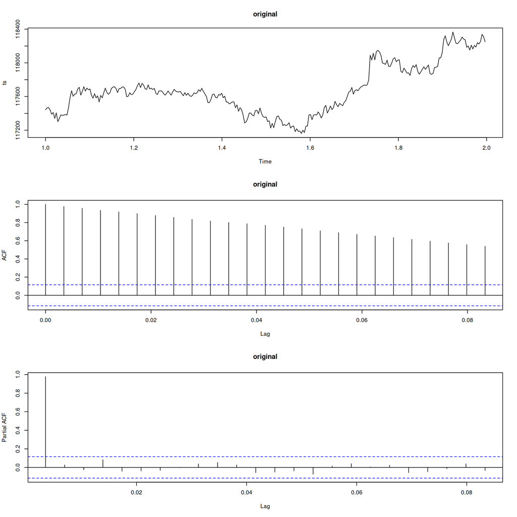

```r
my_plot(price)
```

Як бачимо, графік не схожий на стаціонарний за середнім та і ACF дуже повільно спадає.

Побачимо, яку модель запропонує машина:

```r
check(price)
```

```
## $auto
## Series: model
## ARIMA(0,1,1)
##
## Coefficients:
##           ma1
##       -0.1044
## s.e.   0.0600
##
## sigma^2 = 2457:  log likelihood = -1524.14
## AIC=3052.29   AICc=3052.33   BIC=3059.61
##
## $arma
## Series: model
## ARIMA(0,0,5) with non-zero mean
##
## Coefficients:
##          ma1     ma2     ma3     ma4     ma5         mean
##       1.3876  1.5954  1.3551  0.8911  0.3671  117676.1740
## s.e.  0.0593  0.0857  0.0853  0.0648  0.0493      27.2913
##
## sigma^2 = 5109:  log likelihood = -1636.8
## AIC=3287.59   AICc=3287.99   BIC=3313.24
```

Обрати найпростішу модель, яка дає непогані результати

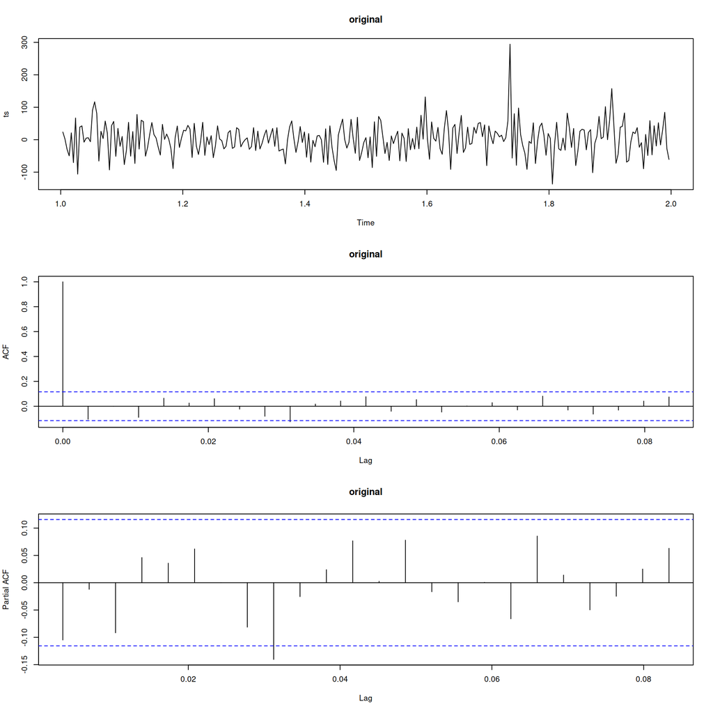

```r
my_plot(diff(price))
```

```r
check(diff(price))
```

```
## $auto
## Series: model
## ARIMA(0,0,1) with zero mean
##
## Coefficients:
##           ma1
##       -0.1044
## s.e.   0.0600
##
## sigma^2 = 2409:  log likelihood = -1524.14
## AIC=3052.29   AICc=3052.33   BIC=3059.61
##
## $arma
## Series: model
## ARIMA(0,0,1) with zero mean
##
## Coefficients:
##           ma1
##       -0.1044
## s.e.   0.0600
##
## sigma^2 = 2409:  log likelihood = -1524.14
## AIC=3052.29   AICc=3052.33   BIC=3059.61
```

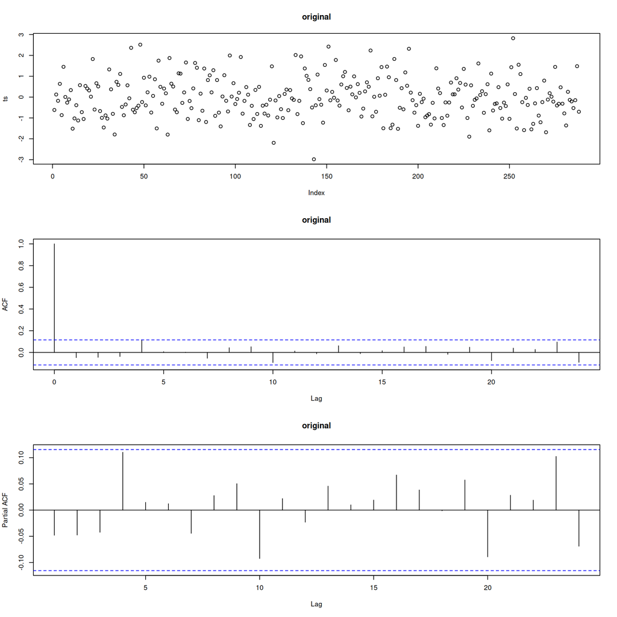

```r
my_plot(rnorm(limit))
```

Проганяючи у себе декілька разів аналіз, початковий ряд дає модель то ARIMA(1, 1, 0) то ARIMA(0, 1, 1). Це явно не нормально, та і продиференційований графік виглядає як білий шум. Отже це або AR(1), або випадкове блукання ARIMA(0, 1, 0). Треба додатково дивитись не тільки на ACF, PACF та більш уважніше